# Part I - (Loan Data from Prosper)

## Multivariate Exploration

### Question

In line with my goal, to see the relationship select categorical variables have with Loan Status, how do these variables appear when compared or are plotted alongside Loan Status?.

### Visualisation 19

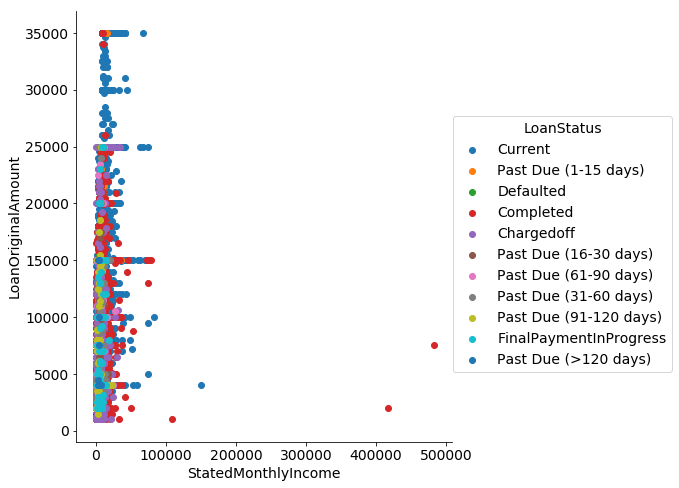

```python
#sb.palplot(sb.color_palette(n_colors=11))
g = sb.FacetGrid(data =loan, hue = 'LoanStatus', size=7, palette=sb.color_palette(n_colors=11))
g.map(plt.scatter, 'StatedMonthlyIncome', 'LoanOriginalAmount')
g.add_legend()
```

### Observation 19

● The plot reinforces that, more low income earners take more and higher loans.

● There a few outlying low income earners with high original loan amounts who have completed their payments.

### Visualisation 20

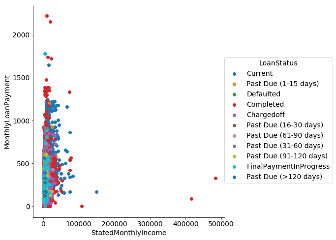

```python
g = sb.FacetGrid(data =loan, hue = 'LoanStatus', size = 7, palette=sb.color_palette(n_colors=11))
g.map(plt.scatter, 'StatedMonthlyIncome', 'MonthlyLoanPayment')
g.add_legend()
```

### Observation 20

● There appears to be no strong correlation between StatedMonthlyIncome and MonthlyLoanPayments.

● Although there are two outlying points showing high earners with low monthly payments that have completed their loan payments.

● There are also a few low income earners with high monthly payments who have completed their payments.

● The plot shows there are more low income earners who take Loans.

### Talk about some of the relationships you observed in this part of the investigation. Were there features that strengthened each other in terms of looking at your feature(s) of interest?

> The features focused on in this part did not strengthen each other in terms of looking at the feature of interest LoanStatus

### Were there any interesting or surprising interactions between features?

> It was interesting to find that there was no strong correlation between the quantitative variables of interest. I was of the opinion that LoanOriginalAmount would increase as StatedMonthlyIncome increased which would reflect on LoanStatus

```python
loan.describe ()
```

[output not shown]

## Conclusions

The investigation was an interesting focusing on how select variables of interest affected the main interest feature LoanStatus. Beginning with plotting the distributions of individual variables, plotting individual variables against the main feature of interest and then plotting two individuals alongside the main feature of interest, finding that:

● More than half of the listings are still paying off their loans, but of remainder, most have completed payment

● High income earners complete their loan payments but they make an almost insubstantial part of the data set. More low income earners take more and higher lows and it is unclear how this affects their loan status. With average of these variables being: StatedMonthlyIncome - 5,893 LoanOriginalAmount - 9,092 MonthlyLoanPayment - 291 AvailableBankcardCredit - 11,482 CreditScoreRangeUpper - 718 ● Although listings under 10,000 with 'completed' as LoanStatus, it is not a clear indication that lower LoanOriginalAmount are more like to get paid off